# Demo: Leaflet Maps

## Making a map with points in R with leaflet

We’re going to be doing a lot of the stuff from the RStudio [leaflet tutorial](https://rstudio.github.io/leaflet/). This walkthrough is a variation of [Amelia McNamara](https://github.com/AmeliaMN)’s version.

Load `leaflet` first:

```r
library(leaflet)
```

Let’s start with a simple map. We create a map widget by calling `leaflet()`, and then add layers (ex. `addTiles`, `addMarkers`, `addPolygons`) to modify the widget.

```r
m <- leaflet() %>%
  setView(-72.518978, 42.381050, zoom = 10) %>%
  addTiles() %>%  # Load the default OpenStreetMap tile set
  addMarkers(lng=-72.6403, lat=42.3163, popup = "Smith!")
m
```

[interactive chart not shown]

Note that the syntax here is similar to that of `ggplot2`. Please consult the [Leaflet documentation](http://rstudio.github.io/leaflet/) for more details.

## Okay, let’s do something with actual data

Lets look at [storm data](http://www.ncdc.noaa.gov/stormevents/ftp.jsp) from the NOAA. It comes in a few files that we need to join together in order to use. For convenience, I’ve put them on the course website. You can download them manually, as .zip files:

```r
library(readr)
library(dplyr)
# One file contains information about the storm
# ignore the warning
stormdetails <- read_csv("too-big-for-git/StormEvents_details-ftp_v1.0_d2023_c20240917.csv")
# The other contains actual location data
stormlocs <- read_csv("too-big-for-git/StormEvents_locations-ftp_v1.0_d2023_c20240917.csv")
# We'll want to use them together, so we'll use a join
storms <- stormlocs %>%
  left_join(stormdetails, by="EVENT_ID")
```

```r
glimpse(storms)
```

```
## Rows: 44,443
## Columns: 60
## $ YEARMONTH          <dbl> 202303, 202303, 202303, 202303, 202303, 202303, 202…
## $ EPISODE_ID.x       <dbl> 176742, 176742, 176742, 176742, 176742, 176742, 176…
## $ EVENT_ID           <dbl> 1074014, 1074015, 1074016, 1074017, 1074018, 107401…
## $ LOCATION_INDEX     <dbl> 1, 1, 1, 1, 1, 1, 1, 1, 1, 1, 1, 1, 1, 1, 1, 1, 2, …
## $ RANGE              <dbl> 2.07, 1.49, 1.67, 0.45, 2.19, 0.00, 3.41, 0.89, 0.5…
## $ AZIMUTH            <chr> "N", "SSW", "W", "ENE", "SSW", "N", "SSW", "NW", "W…
## $ LOCATION           <chr> "ABERNATHY ARPT", "PROSPECT", "NASHVILLE", "GOODLET…
## $ LATITUDE           <dbl> 35.1800, 35.0100, 36.1700, 36.3220, 36.3394, 36.320…
## $ LONGITUDE          <dbl> -87.0500, -87.0100, -86.8100, -86.7123, -86.7100, -…
## $ LAT2               <dbl> 3510800, 35600, 3610200, 3619320, 3620364, 3619200,…
## $ LON2               <dbl> 873000, 87600, 8648600, 8642738, 8642600, 8643200, …
## $ BEGIN_YEARMONTH    <dbl> 202303, 202303, 202303, 202303, 202303, 202303, 202…
## $ BEGIN_DAY          <dbl> 3, 3, 3, 3, 3, 3, 3, 3, 3, 3, 3, 1, 3, 3, 3, 2, 2, …
```

[output cut: 47 more lines]

## Mapping lightning strikes

Let’s pull out the lightning strikes and map them as part of a `dplyr` chain

```r
lightning_map <- storms %>%               # Start with the storm data
  filter(EVENT_TYPE == "Lightning") %>%   # Filter down to just the lightning events
  leaflet() %>%
    addTiles() %>%
    addMarkers(~LONGITUDE, ~LATITUDE, popup = "Zap!")

lightning_map
```

[interactive chart not shown]

## Challenge:

- Find another storm type to map
- Bonus– add popups!

## One approach

```r
mtw_map <- storms %>%
  filter(EVENT_TYPE == "Marine Thunderstorm Wind") %>%
  leaflet() %>%
    addTiles() %>%
    addMarkers(~LONGITUDE, ~LATITUDE, popup = ~EVENT_NARRATIVE)

mtw_map
```

[interactive chart not shown]

## Polygons

First let’s grab some data (and do a little conversion)

```r
tornados <- storms %>%
  filter(EVENT_TYPE=="Tornado") %>%
  mutate(DAMAGE_PROPERTY = as.numeric(sub("K", "", DAMAGE_PROPERTY, fixed = TRUE)))
```

Then let’s start with something easy(ish) – circles

```r
m <- leaflet(data = tornados) %>%
  addTiles() %>%
  addCircles(~LONGITUDE, ~LATITUDE,
             weight = 1,
             radius = ~DAMAGE_PROPERTY*100, # Map the radius of the circle to amount of damage
             popup = ~EVENT_NARRATIVE)      # Include details about the tornado
m
```

[interactive chart not shown]

## Polgyons come in shapefiles

Most boundaries (state, national, etc) are provided in terms of polygons. Major mapping software ArcGIS, from ESRI, has essentially set the standard formats. There are many files with different extensions: .prj (the projection), .shp (the shapefile), .cpg (??), .dbf (??), .shx (??).

You need special software or packages to work with shapefiles.

## State shapefiles

This portion of the tutorial is based on: [R Graph Gallery](https://r-graph-gallery.com/168-load-a-shape-file-into-r.html)

I got the shapefiles used below from [the Census](https://www.census.gov/geo/maps-data/data/cbf/cbf_state.html). You can choose the resolution. If you want, the zipfile of the shapes I used is on the course website (cb_2018_us_state_500k.zip).

We’re going to use the `sf` package to deal with shapefiles. The sf package offers the `st_read()` and the `read_sf()` functions that allow us to read shapefile using the following syntax.

As a result you get a geospatial object (`my_sf` here) that contains all the information we need for further mapping.

```r
library(sf)
my_sf <- read_sf("too-big-for-git/cb_2018_us_state_500k/cb_2018_us_state_500k.shp")

print(my_sf) #tells you the max and min coordinates, the kind of projection in use and the the first few rows of the data associated with the regions.
```

```
## Simple feature collection with 56 features and 9 fields
## Geometry type: MULTIPOLYGON
## Dimension:     XY
## Bounding box:  xmin: -179.1489 ymin: -14.5487 xmax: 179.7785 ymax: 71.36516
## Geodetic CRS:  NAD83
## # A tibble: 56 × 10
##    STATEFP STATENS  AFFGEOID    GEOID STUSPS NAME          LSAD    ALAND  AWATER
##    <chr>   <chr>    <chr>       <chr> <chr>  <chr>         <chr>   <dbl>   <dbl>
##  1 28      01779790 0400000US28 28    MS     Mississippi   00    1.22e11 3.93e 9
##  2 37      01027616 0400000US37 37    NC     North Caroli… 00    1.26e11 1.35e10
##  3 40      01102857 0400000US40 40    OK     Oklahoma      00    1.78e11 3.37e 9
##  4 51      01779803 0400000US51 51    VA     Virginia      00    1.02e11 8.53e 9
##  5 54      01779805 0400000US54 54    WV     West Virginia 00    6.23e10 4.89e 8
##  6 22      01629543 0400000US22 22    LA     Louisiana     00    1.12e11 2.38e10
##  7 26      01779789 0400000US26 26    MI     Michigan      00    1.47e11 1.04e11
##  8 25      00606926 0400000US25 25    MA     Massachusetts 00    2.02e10 7.13e 9
##  9 16      01779783 0400000US16 16    ID     Idaho         00    2.14e11 2.39e 9
## 10 12      00294478 0400000US12 12    FL     Florida       00    1.39e11 3.14e10
## # ℹ 46 more rows
## # ℹ 1 more variable: geometry <MULTIPOLYGON [°]>
```

```r
nrow(my_sf) #how many regions you have
```

```
## [1] 56
```

Notice how each region has a POLYGON associated with it.

## Mapping shapefiles

We can map shapefiles using `ggplot2` and the `geom_sf()` function:

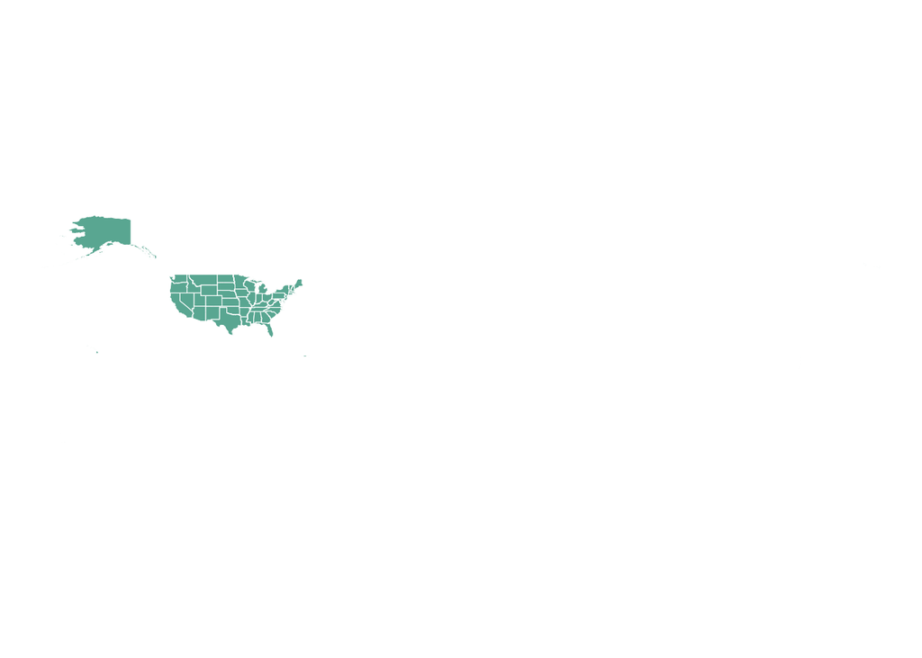

```r
library(ggplot2)

ggplot(my_sf) +
  geom_sf(fill = "#69b3a2", color = "white") +
  theme_void()
```

What if we want just a specific region?

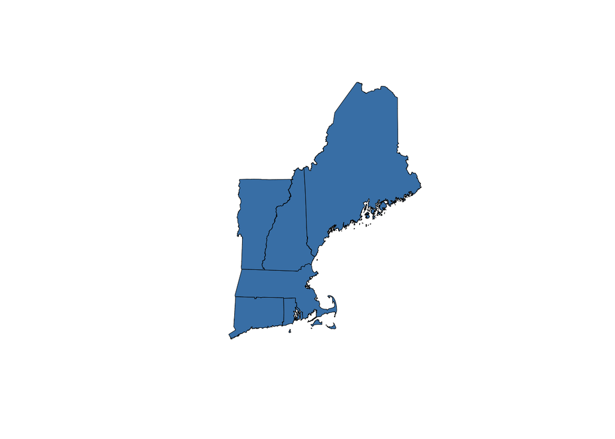

```r
newEngland <- my_sf[(my_sf$STUSPS == "ME" | my_sf$STUSPS == "NH" | my_sf$STUSPS == "VT" |
                      my_sf$STUSPS == "MA" | my_sf$STUSPS == "RI" | my_sf$STUSPS == "CT"), ]

plot(st_geometry(newEngland),
  col = "steelblue", lwd = 0.5
)
```

## Your Turn!

Put it all together! See if you can make a map of your own data, and embed it within a dashboard. **Bonus:** can you make them interact with one another?